# Background: DNA methylation and how it is measured

This notebook covers background on DNA methylation and the array technology used to measure DNA methylation. If you are already familiar with methylation arrays, skip ahead to Setup.

# What is DNA methylation

DNA methylation is an epigenetic mechanism that occurs when a methyl (CH3) group is added to a cytosine base in DNA. Methylated cytosines often occur directly next to a guanine nucleotide, which has led to the name of methylated sites as ‘CpGs’ (cytosine-phosphate-guanine). The added methyl group of a CpG can physically inhibit the cellular machinery necessary for gene expression, thus we can infer effects of gene expression from methylation status.

In the human genome, there are GC-rich regions known as CpG islands (CGIs). These regions typically span 500-1500 base pairs (bp) with greater than 60% GC-content. CGIs tend to be in the promoter regions of genes. While 70-80% of CpGs genome-wide are methylated, CGIs are predominantly unmethylated, particularly at active promoters. There are CpGs outside of CGIs, however, and based on their distance from the CGI they may be labeled as in the ‘shore’ (0-2kb), ‘shelf’ (2kb-4kb), or ‘open sea’ ( greater than 4kb).

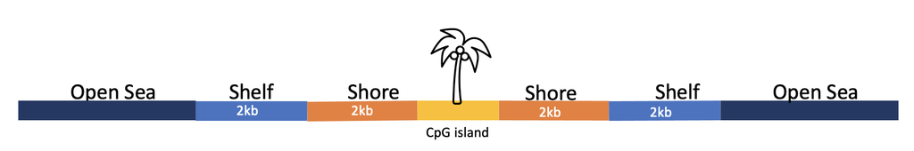

CGI and relative regions

The unique and important characteristic of methylation compared with genetic variants is that methylation status can change over time as a response to environmental factors and is reversible. For example, there are distinct methylation patterns observed between exposure to commercial tobacco smoking and people who have never smoked. After a person quits smoking, their methylation patterns revert back to a state more similar to that of someone who has never smoked.

# Measuring methylation

Array technology, such as the Illumina Infinium Methylation EPIC array (v1, “850K”), estimate the methylation status at a CpG site by the fraction of DNA molecules carrying a methyl group at that specific genomic location. The EPIC array interrogates ~865,000 CpGs across the genome. For each CpG it reports two intensities:

- **M** — signal from the *methylated* allele,
- **U** — signal from the *unmethylated* allele.

From those two numbers we form the two estimates/metrics of methylation status used in methylation analyses:

$$\beta = \frac{M}{M + U + \alpha}, \qquad M\text{-value} = \log_2\!\frac{M}{U}$$

The **beta value** is the direct proportion of methylation and values range between $[0,1]$. While the beta value is easily interpretable, the distribution of beta values are often non-normal and thus violate assumptions of normality when they are used in linear regression modeling. Thus, the beta values are logit-transformed, $M = \log_2\left(\beta / (1 - \beta)\right)$, to produce **M-values**. M-values are unbounded in range, and roughly homoscedastic in distribution, which makes it the better choice for statistical modeling. ($\alpha \approx 100$ is a small offset that stabilizes betas where total intensity is low.)

**TipTwo probe designs**

Methylation array technology often uses two different probe chemistries.

- **Type I** probes use two beads (one for M, one for U) in the *same* color channel;
- **Type II** probes use a single bead and read M vs U in the *two* color channels. Type I probes are better suited for regions with high CpG density, but require double the physical space on the array per locus. Type II are more compact, but have reduced sensitivity in high density regions.

Normalization is done to allow for these different probe types to be compared.

A short history of the Illumina methylation platforms:

| Array | CpGs (approx.) | Notes |
| --- | --- | --- |
| HumanMethylation27 | 27,000 | promoter-focused, largely retired |
| HumanMethylation450 | 485,000 | the workhorse of the 2010s |
| **MethylationEPIC v1** | **865,000** | **this tutorial** (GPL21145) |
| MethylationEPIC v2 | 935,000 | current; different probe IDs |

The dataset we will use in this tutorial is EPIC **v1**, but the same framework can be applied for other arrays.

# Where to go next

Setup introduces the Grady Trauma Project subset, shows how to download the raw IDAT files, and lays out what running the whole tutorial costs in time, memory, and disk.